# HW5

Sara Kutbay

April 25, 2017

# Problem

Hometown Bank would like to improve its status in the term deposit market. Currently, only around 12% of bank customers have subscribed to a term deposit, and Hometown would like to increase this number in order to increase the number of open accounts and overall revenue. The bank has provided a large customer data set to analyze for any trends or insights that could aid in their approach.

# Question to Answer

Can we uncover what factors are linked to a customer subscribing to a term deposit, and can we use these predictors to encourage more subscriptions in the future?

# Analysis

1. Logistic Regression - This model will help us to determine what specific variables are predictors of a customer subscribing to a term deposit.
2. Decision Tree - This model can be utilized by non-technical bank resources in order to encourage term deposit subscriptions through a visual representation.
3. Cluster Analysis - We can see whether or not customers can be grouped into clusters and if certain clusters are more likely to subscribe to a term deposit.

# Data Preparation

### Read in Data Set

```r
bank_full<-read.csv("C:/Users/SK030875/Desktop/MBA/BIA6307_new/HW5/data/bank-full.csv")
```

### Rearrange Columns so that Target Variable is First

```r
bank<-bank_full[,c(17,1:16)]
names(bank)
```

```
##  [1] "y..category"         "age..number"         "job..category"
##  [4] "marital..category"   "education..category" "default..category"
##  [7] "balance..number"     "housing..category"   "loan..category"
## [10] "contact..category"   "day..number"         "month..category"
## [13] "duration..number"    "campaign..number"    "pdays..number"
## [16] "previous..number"    "poutcome..category"
```

### Initial View of Data Set Dimensions and Target Variable

```r
dim(bank)
```

```
## [1] 45211    17
```

```r
table(bank$y..category)
```

```
##
##    no   yes
## 39922  5289
```

### Install Packages

```r
#install.packages("rpart", lib="/Users/SK030875/Desktop/MBA/BIA6307_new/Packages/")
#install.packages("rpart.plot", lib="/Users/SK030875/Desktop/MBA/BIA6307_new/Packages/")
```

# Logistic Regression

## Assumptions

### Preparation for Logistic Regression

```r
bank1 <- bank[,c(1:9, 13:14)]
bank1$age..number <- ifelse(bank1$age..number > 40, 1, 0)
bank1$y..category <- ifelse(bank1$y..category == "yes", 1, 0)
bank1$job..category <- ifelse((bank1$job..category == "admin." |
                              bank1$job..category == "management" |
                              bank1$job..category == "housemaid" |
                              bank1$job..category == "entrepreneur" |
                              bank1$job..category == "blue-collar" |
                              bank1$job..category == "self-employed" |
                              bank1$job..category == "technician" |
                              bank1$job..category == "services"), 1, 0)
bank1$marital..category <- ifelse(bank1$marital..category == "married", 1, 0)
bank1$education..category <- ifelse((bank1$education..category == "unknown" |
                                     bank1$education..category == "primary"), 1, 0)
bank1$default..category <- ifelse(bank1$default..category == "yes", 1, 0)
bank1$balance..number <- ifelse(bank1$balance..number > 0, 1, 0)
bank1$housing..category <- ifelse(bank1$housing..category == "yes", 1, 0)
bank1$loan..category <- ifelse(bank1$loan..category == "yes", 1, 0)
bank1$duration..number <- ifelse(bank1$duration..number > 300, 1, 0)
bank1$campaign..number <- ifelse(bank1$campaign..number > 3, 1, 0)
```

### Run Regression Model and Change to Odds Ratios

```r
bank_regression<-glm(bank1$y..category~., data=bank1, family=binomial())
exp(cbind(bank_odds=coef(bank_regression)))
```

```
##                     bank_odds
## (Intercept)         0.1388287
## age..number         0.9375736
## job..category       0.5682391
## marital..category   0.7496617
## education..category 0.7146389
## default..category   0.7394888
## balance..number     1.7029556
## housing..category   0.4041298
## loan..category      0.5557665
## duration..number    6.9133607
## campaign..number    0.5897858
```

### Check for significance

```r
anova(bank_regression,test="Chisq")
```

```
## Analysis of Deviance Table
##
## Model: binomial, link: logit
##
## Response: bank1$y..category
##
## Terms added sequentially (first to last)
##
##
##                     Df Deviance Resid. Df Resid. Dev  Pr(>Chi)
## NULL                                45210      32631
## age..number          1      3.7     45209      32627   0.05406 .
## job..category        1    427.4     45208      32200 < 2.2e-16 ***
## marital..category    1    128.9     45207      32071 < 2.2e-16 ***
## education..category  1     58.8     45206      32012 1.706e-14 ***
## default..category    1     25.2     45205      31987 5.203e-07 ***
## balance..number      1    172.0     45204      31815 < 2.2e-16 ***
## housing..category    1    665.7     45203      31149 < 2.2e-16 ***
## loan..category       1    145.2     45202      31004 < 2.2e-16 ***
## duration..number     1   3905.8     45201      27098 < 2.2e-16 ***
## campaign..number     1    149.8     45200      26948 < 2.2e-16 ***
## ---
## Signif. codes:  0 '***' 0.001 '**' 0.01 '*' 0.05 '.' 0.1 ' ' 1
```

### From the model, we see that customers who had a contact duration of greater than 5 minutes during their last contact were almost 7 times more likely to subscribe to a term deposit. Additionally, customers with a positive balance were almost twice as likely to subscribe. These are key factors that Hometown Bank should focus on when pitching term deposit subscriptions to customers.

# Decision Tree

## Assumptions

### We can use the data set in its original form when performing the decision tree, as it will handle the different types of variables.

### Preparation for Decision Tree

```r
bank2 <- bank
```

### Use rpart to Build a Decision Tree

```r
library(rpart, lib.loc="/Users/SK030875/Desktop/MBA/BIA6307_new/Packages/")
bank_rpart <- rpart(bank2$y..category~., method="class", parms = list(split="gini"), data=bank2)
```

### Prune and Visualize the Decision Tree

```r
library(rpart.plot, lib.loc="/Users/SK030875/Desktop/MBA/BIA6307_new/Packages/")
cptable<-printcp(bank_rpart)
```

```
##
## Classification tree:
## rpart(formula = bank2$y..category ~ ., data = bank2, method = "class",
##     parms = list(split = "gini"))
##
## Variables actually used in tree construction:
## [1] duration..number   poutcome..category
##
## Root node error: 5289/45211 = 0.11698
##
## n= 45211
##
##         CP nsplit rel error  xerror     xstd
## 1 0.038003      0   1.00000 1.00000 0.012921
## 2 0.025336      3   0.88599 0.90263 0.012355
## 3 0.017016      4   0.86065 0.87030 0.012157
## 4 0.010000      5   0.84364 0.85612 0.012069
```

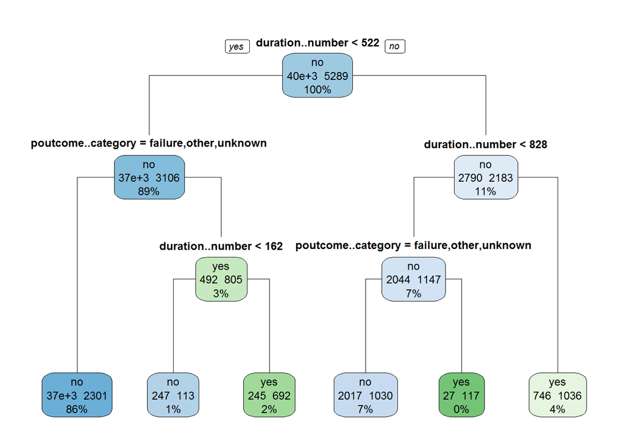

```r
set.cp.value<-cptable[which.min(cptable[,"xerror"]),"CP"]
Pruned_bank_rpart <- prune(bank_rpart, cp=set.cp.value)

rpart.plot(Pruned_bank_rpart, type=1, extra=101)
```

# Cluster Analysis

## Assumptions

### We need to use the same modified data set that we used for logistic regression, as we want all variables represented as binary values. We will try k = 3, k = 4, and k = 5.

### Perform cluster analysis for each k value

```r
set.seed(123)
bank_clusters_3 <- kmeans(bank1, centers=3)
bank_clusters_4 <- kmeans(bank1, centers=4)
bank_clusters_5 <- kmeans(bank1, centers=5)
```

### Cluster Separation

```r
clusters3<- bank_clusters_3$betweenss/bank_clusters_3$totss
clusters4<- bank_clusters_4$betweenss/bank_clusters_4$totss
clusters5<- bank_clusters_5$betweenss/bank_clusters_5$totss

betweenss.metric <- c(clusters3, clusters4, clusters5)
print(betweenss.metric)
```

```
## [1] 0.1659178 0.2642442 0.3173550
```

### k=5 has the most separation.

### Cluster Cohesion

```r
clusters3<- bank_clusters_3$tot.withinss/bank_clusters_3$totss
clusters4<- bank_clusters_4$tot.withinss/bank_clusters_4$totss
clusters5<- bank_clusters_5$tot.withinss/bank_clusters_5$totss

totwithinss.metric <- c(clusters3, clusters4, clusters5)
print(totwithinss.metric)
```

```
## [1] 0.8340822 0.7357558 0.6826450
```

### k=5 also has the most cluster cohesion.

### We will use k = 5

### Put clusters in data frame

```r
Clusters_5<-data.frame(bank_clusters_5$centers)
Clusters_5<-data.frame(t(bank_clusters_5$centers))
```

### Sort the centroids for each cluster

```r
Clusters_5[order(-Clusters_5$X1), ]
```

```
##                             X1         X2         X3         X4         X5
## age..number         0.99026661 0.00000000 0.46341831 0.00000000 1.00000000
## balance..number     0.86288616 0.82176072 0.85955649 0.85586379 0.82969706
## marital..category   0.81887431 0.54534648 0.46824559 0.42184060 0.75082405
## education..category 0.76809141 0.13880148 0.09383014 0.09980919 0.14055878
## job..category       0.50042319 0.96245018 0.89289486 0.88888889 0.96641030
## duration..number    0.29348286 0.23795539 0.98657414 0.00000000 0.07408570
## campaign..number    0.22344477 0.19439200 0.18117363 0.23058858 0.23803171
## housing..category   0.12928481 1.00000000 0.30577764 0.00000000 0.64283472
## loan..category      0.12759204 0.17278512 0.14029265 0.13694408 0.18105478
## y..category         0.10960643 0.01825047 0.49781264 0.11301923 0.03453147
## default..category   0.01438849 0.01839032 0.01719716 0.02157640 0.01750118
```

```r
Clusters_5[order(-Clusters_5$X2), ]
```

```
##                             X1         X2         X3         X4         X5
## housing..category   0.12928481 1.00000000 0.30577764 0.00000000 0.64283472
## job..category       0.50042319 0.96245018 0.89289486 0.88888889 0.96641030
## balance..number     0.86288616 0.82176072 0.85955649 0.85586379 0.82969706
## marital..category   0.81887431 0.54534648 0.46824559 0.42184060 0.75082405
## duration..number    0.29348286 0.23795539 0.98657414 0.00000000 0.07408570
## campaign..number    0.22344477 0.19439200 0.18117363 0.23058858 0.23803171
## loan..category      0.12759204 0.17278512 0.14029265 0.13694408 0.18105478
## education..category 0.76809141 0.13880148 0.09383014 0.09980919 0.14055878
## default..category   0.01438849 0.01839032 0.01719716 0.02157640 0.01750118
## y..category         0.10960643 0.01825047 0.49781264 0.11301923 0.03453147
## age..number         0.99026661 0.00000000 0.46341831 0.00000000 1.00000000
```

```r
Clusters_5[order(-Clusters_5$X3), ]
```

```
##                             X1         X2         X3         X4         X5
## duration..number    0.29348286 0.23795539 0.98657414 0.00000000 0.07408570
## job..category       0.50042319 0.96245018 0.89289486 0.88888889 0.96641030
## balance..number     0.86288616 0.82176072 0.85955649 0.85586379 0.82969706
## y..category         0.10960643 0.01825047 0.49781264 0.11301923 0.03453147
## marital..category   0.81887431 0.54534648 0.46824559 0.42184060 0.75082405
## age..number         0.99026661 0.00000000 0.46341831 0.00000000 1.00000000
## housing..category   0.12928481 1.00000000 0.30577764 0.00000000 0.64283472
## campaign..number    0.22344477 0.19439200 0.18117363 0.23058858 0.23803171
## loan..category      0.12759204 0.17278512 0.14029265 0.13694408 0.18105478
## education..category 0.76809141 0.13880148 0.09383014 0.09980919 0.14055878
## default..category   0.01438849 0.01839032 0.01719716 0.02157640 0.01750118
```

```r
Clusters_5[order(-Clusters_5$X4), ]
```

```
##                             X1         X2         X3         X4         X5
## job..category       0.50042319 0.96245018 0.89289486 0.88888889 0.96641030
## balance..number     0.86288616 0.82176072 0.85955649 0.85586379 0.82969706
## marital..category   0.81887431 0.54534648 0.46824559 0.42184060 0.75082405
## campaign..number    0.22344477 0.19439200 0.18117363 0.23058858 0.23803171
## loan..category      0.12759204 0.17278512 0.14029265 0.13694408 0.18105478
## y..category         0.10960643 0.01825047 0.49781264 0.11301923 0.03453147
## education..category 0.76809141 0.13880148 0.09383014 0.09980919 0.14055878
## default..category   0.01438849 0.01839032 0.01719716 0.02157640 0.01750118
## age..number         0.99026661 0.00000000 0.46341831 0.00000000 1.00000000
## housing..category   0.12928481 1.00000000 0.30577764 0.00000000 0.64283472
## duration..number    0.29348286 0.23795539 0.98657414 0.00000000 0.07408570
```

```r
Clusters_5[order(-Clusters_5$X5), ]
```

```
##                             X1         X2         X3         X4         X5
## age..number         0.99026661 0.00000000 0.46341831 0.00000000 1.00000000
## job..category       0.50042319 0.96245018 0.89289486 0.88888889 0.96641030
## balance..number     0.86288616 0.82176072 0.85955649 0.85586379 0.82969706
## marital..category   0.81887431 0.54534648 0.46824559 0.42184060 0.75082405
## housing..category   0.12928481 1.00000000 0.30577764 0.00000000 0.64283472
## campaign..number    0.22344477 0.19439200 0.18117363 0.23058858 0.23803171
## loan..category      0.12759204 0.17278512 0.14029265 0.13694408 0.18105478
## education..category 0.76809141 0.13880148 0.09383014 0.09980919 0.14055878
## duration..number    0.29348286 0.23795539 0.98657414 0.00000000 0.07408570
## y..category         0.10960643 0.01825047 0.49781264 0.11301923 0.03453147
## default..category   0.01438849 0.01839032 0.01719716 0.02157640 0.01750118
```

### Cluster 1 - Married people over 40 with a positive balance

### Cluster 2 - People with home loans who can pay for them

### Cluster 3 - People who have needed longer contact help from the bank

### Cluster 4 - Grab bag of people

### Cluster 5 - Older employed folks.

### Check if any particular clusters are more likely to subscribe to term deposits

```r
bank1$cluster <- bank_clusters_5$cluster
aggregate(data = bank1, bank1$y..category ~ cluster, mean)
```

```
##   cluster bank1$y..category
## 1       1        0.10960643
## 2       2        0.01825047
## 3       3        0.49781264
## 4       4        0.11301923
## 5       5        0.03453147
```

### Cluster 3 (people who had longer durations of contact with the bank) contain the majority of people who subscribed to a term deposit.

# Recommendations